# Decline in cart-to-purchase conversion

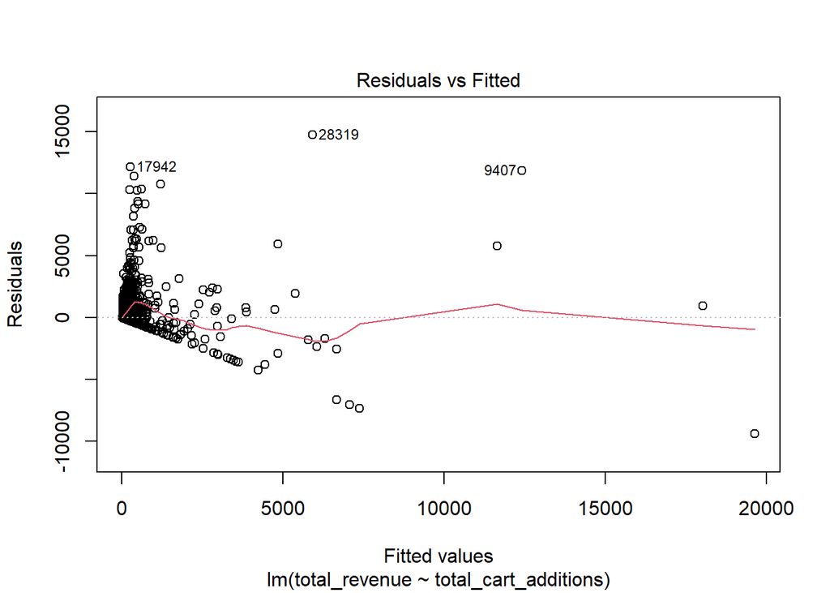

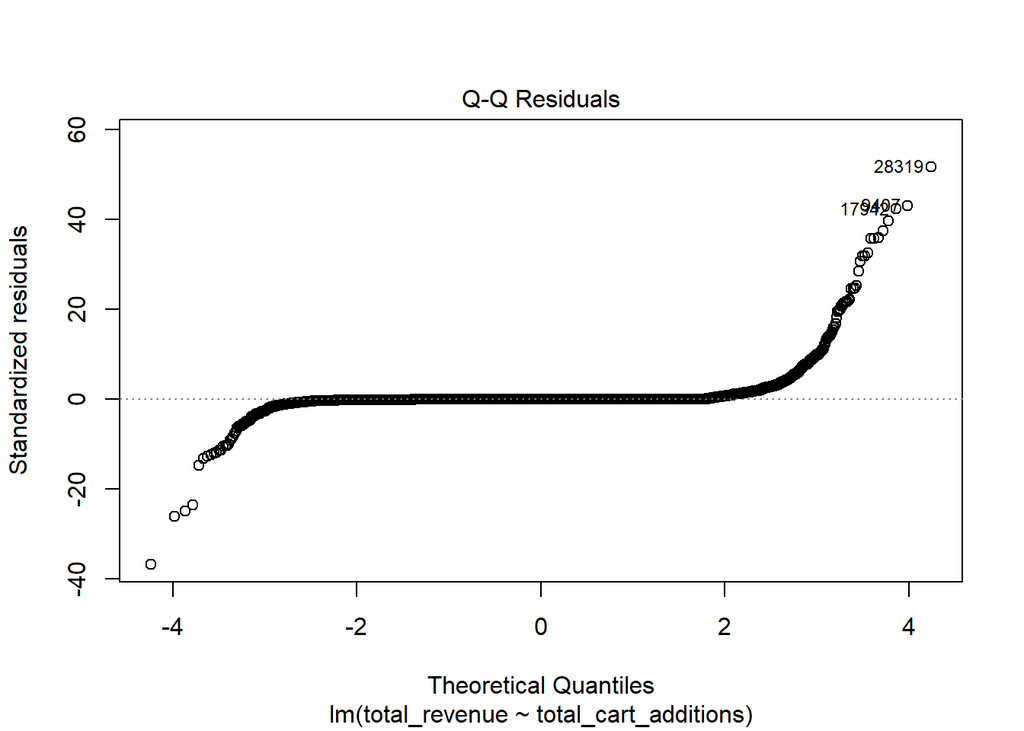

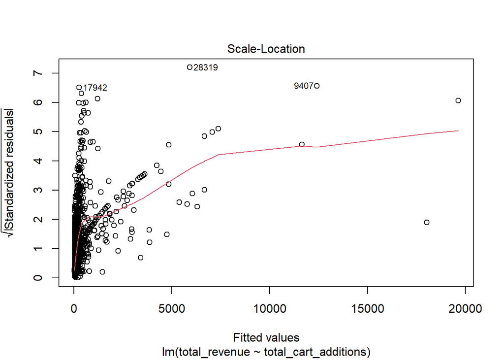

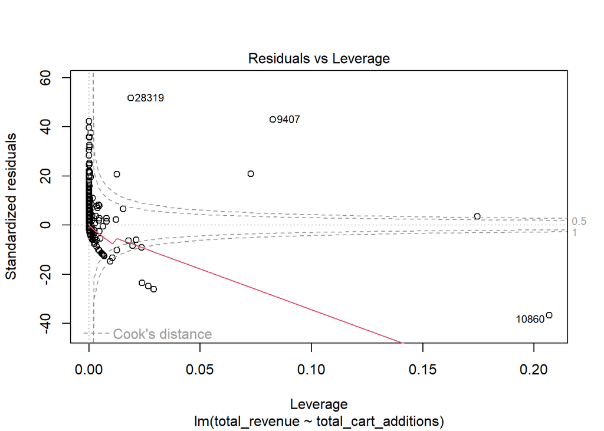

```r
plot(model_revenue)
```

```r
# Calculate Cook's Distance
cooks_distance <- cooks.distance(model_revenue)

# Add Cook's Distance to the dataset for analysis
session_data$cooks_distance <- cooks_distance

# Threshold for identifying influential points
threshold <- 4 / nrow(session_data)

# Identify high-leverage points
high_leverage_points <- which(cooks_distance > threshold)

# Display high-leverage points
cat("Number of high-leverage points:", length(high_leverage_points), "\n")
```

```
## Number of high-leverage points: 434
```

```r
cat("High-leverage points indices:\n")
```

```
## High-leverage points indices:
```

```r
print(high_leverage_points)
```

[output not shown]

[output cut: 53 more lines]

```r
# View the corresponding rows in the dataset
high_leverage_data <- session_data[high_leverage_points, ]
head(high_leverage_data)
```

| user_session | total_cart_additions | total_revenue | total_purchases | revenue_log | revenue_sqrt | cart_to_purchase_ratio | cooks_distance |
| --- | --- | --- | --- | --- | --- | --- | --- |
| 03eK5DOgJH | 297 | 482.52 | 1 | 6.179022 | 21.96634 | 0.003367003 | 0.0202311803 |
| 09mMZBPW82 | 259 | 0.00 | 0 | 0.000000 | 0.00000 | 0.000000000 | 0.0215219372 |
| 0GQhWvvCqz | 18 | 1802.21 | 5 | 7.496769 | 42.45244 | 0.277777778 | 0.0004646769 |
| 0N1HfpHuL2 | 78 | 2053.10 | 14 | 7.627106 | 45.31115 | 0.179487179 | 0.0020384941 |
| 0mteBHYVG3 | 348 | 686.92 | 7 | 6.532218 | 26.20916 | 0.020114943 | 0.0324213169 |
| 0xK0NcurV1 | 84 | 0.00 | 0 | 0.000000 | 0.00000 | 0.000000000 | 0.0002749162 |

```r
# Remove high-leverage points from the dataset
session_data_filtered <- session_data[-high_leverage_points, ]

# Refit the model with the filtered data
model_revenue_filtered <- lm(total_revenue ~ total_cart_additions, data = session_data_filtered)

# Summary of the updated model
summary(model_revenue_filtered)
```

```
##
## Call:
## lm(formula = total_revenue ~ total_cart_additions, data = session_data_filtered)
##
## Residuals:
##    Min     1Q Median     3Q    Max
## -453.7   -4.6   -4.6   -4.6  812.7
##
## Coefficients:
##                      Estimate Std. Error t value Pr(>|t|)
## (Intercept)           4.60220    0.28768    16.0   <2e-16 ***
## total_cart_additions  7.48459    0.07089   105.6   <2e-16 ***
## ---
## Signif. codes:  0 '***' 0.001 '**' 0.01 '*' 0.05 '.' 0.1 ' ' 1
##
## Residual standard error: 59.44 on 44247 degrees of freedom
## Multiple R-squared:  0.2012, Adjusted R-squared:  0.2012
## F-statistic: 1.115e+04 on 1 and 44247 DF,  p-value: < 2.2e-16
```

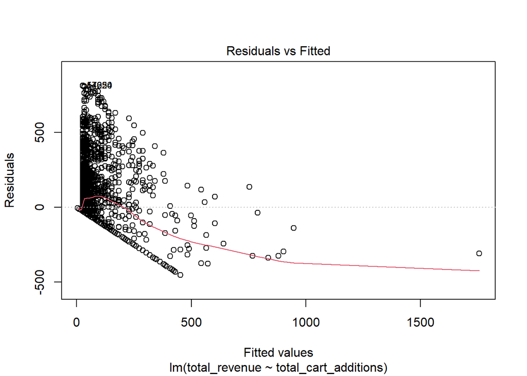

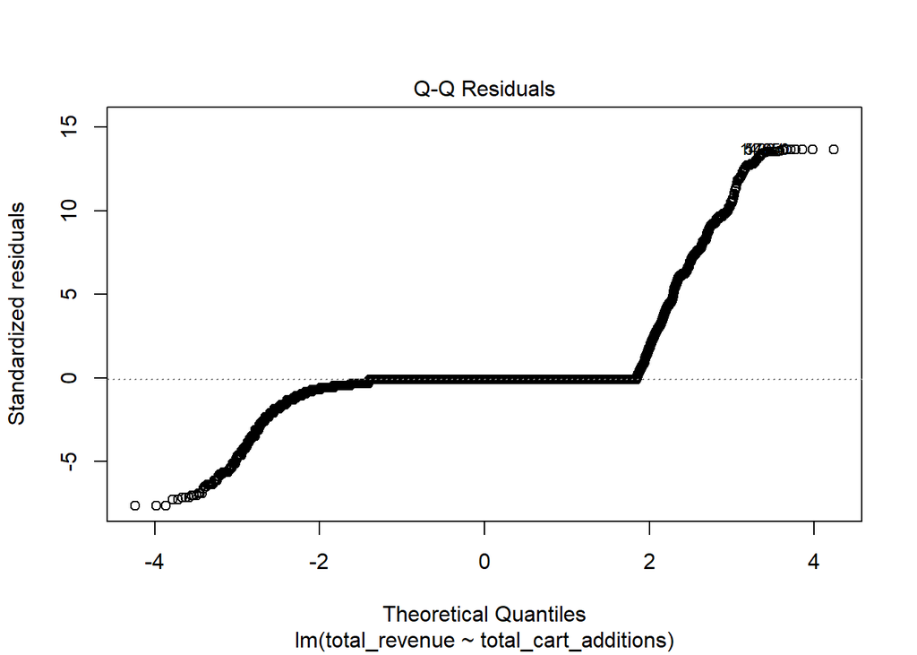

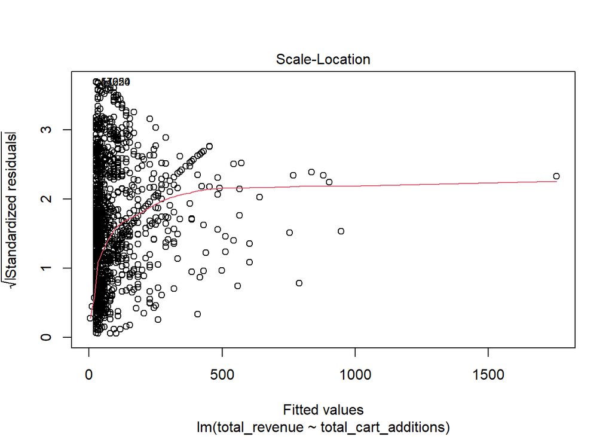

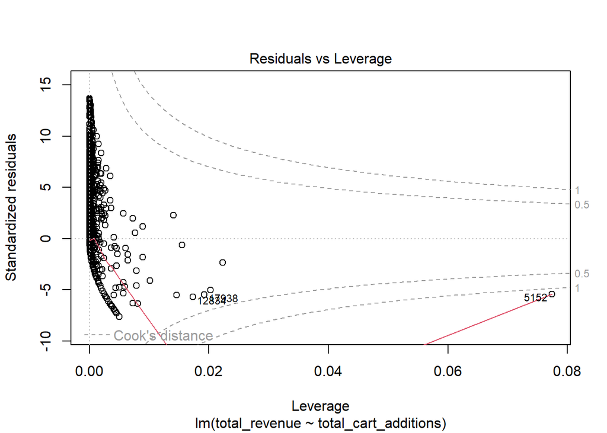

```r
# Diagnostic plots for the new model
plot(model_revenue_filtered)
```

## Step 8c: Predict revenue impact

```r
# Step 7: Predict the impact of a 20% increase in cart additions
current_cart_additions <- sum(session_data$total_cart_additions, na.rm = TRUE)
current_revenue <- coef(model_revenue)[1] + coef(model_revenue)[2] * current_cart_additions
increased_cart_additions <- current_cart_additions * 1.2
increased_revenue <- coef(model_revenue)[1] + coef(model_revenue)[2] * increased_cart_additions

impact <- increased_revenue - current_revenue

cat("\nCurrent Revenue :", current_revenue, "\n")
```

```
##
## Current Revenue : 586154.2
```

```r
cat("Increased Revenue :", increased_revenue, "\n")
```

```
## Increased Revenue : 703381.4
```

```r
cat("Impact of 20% Increase in Cart Additions:", impact, "\n")
```

```
## Impact of 20% Increase in Cart Additions: 117227.2
```

# **Recommended Solutions**

## **Overview**

The following strategies for recovering lost revenue are based on our analysis, including results from the random forest model. This model was the most successful at identifying the key factors driving cart-to-purchase conversions, allowing us to recommend targeted actions to influence conversion that are grounded in statistical insights.

## **Key Findings**

The analysis identified the following variables as the most significant predictors of cart-to-purchase conversions:

1. **Cart Count**: Users adding more items to their cart are significantly more likely to convert.
2. **Session Duration**: Longer session times are associated with higher conversion rates.
3. **Views Count**: Engaged users who explore more products are more likely to make a purchase.
4. **Price**: Low to mid-range priced items (<$300) are most likely to convert, while higher-priced items show a drop in conversions.
5. **Category Diversity**: Users interacting with multiple categories of products are more likely to purchase.
6. **Category_1**: Specific high-level product categories influence the likelihood of conversion.

## **Recommended Strategies**

### **1. Maximize Cart Additions**

- **Why?** Modeling results show that cart count is the strongest driver of conversion.
- **Action Steps:**
  - Encourage users to add items to their cart through notifications or prompts.
  - Use cart abandonment reminders to re-engage users who haven’t completed their purchases.
  - Offer incentives for adding multiple items to the cart (e.g., free shipping thresholds).

### **2. Increase Session Duration**

- **Why?** Users with longer sessions are statistically more likely to convert.
- **Action Steps:**
  - Add personalized recommendations and curated product collections to extend browsing time.
  - Improve navigation and site speed to reduce friction during the shopping experience.
  - Introduce features like “Recently Viewed” or “You May Also Like” to encourage more engagement.

### **3. Boost Product Views**

- **Why?** Users who explore more products tend to have a higher likelihood of purchase.
- **Action Steps:**
  - Highlight popular products on the homepage to catch attention.
  - Use algorithms to suggest products similar to those already viewed.
  - Display cross-sell suggestions on product pages to promote complementary items.

### **4. Target Optimal Price Points**

- **Why?** Our analysis shows low to mid-range priced items (<$300) have the highest conversion likelihood.
- **Action Steps:**
  - Offer discounts or promotions on mid-range products to boost conversions.
  - Bundle products to create value-driven offers for users.
  - Use dynamic pricing to align prices with user demand and behavior.

### **5. Encourage Category Exploration**

- **Why?** Users engaging with diverse product categories are more likely to purchase.
- **Action Steps:**
  - Promote multi-category bundles (e.g., “Complete Your Look” or “Best Deals in Every Category”).
  - Target users with ads or emails showcasing products from less explored categories.
  - Highlight diverse product ranges in campaigns to appeal to varied user interests.

### **Limitations**

- **Assumptions in Data Distribution:** The analysis assumes that the purchase decline is distributed randomly across sessions, categories, and price points. This may not capture systemic biases or specific external factors affecting user behavior (e.g., seasonal trends or market conditions).
- **Incomplete Data:** The dataset may include noise or missing values, particularly in categorical fields (e.g., brand, category_code). While cleaning and deduplication were performed, the impact of incomplete or inaccurate data on model performance cannot be ruled out.
- **Model Simplifications:** Predictive models were built using selected features, which may overlook additional factors (e.g., external economic indicators, promotional campaigns) that could influence cart-to-purchase behavior.
- **Simulation Limitations:** The simulated April dataset assumes the success of interventions (e.g., promoting high-likelihood sessions) without considering real-world constraints like user engagement limits or marketing resource availability.

## **Conclusion**

To address the decline in the cart-to-purchase ratio, the focus should be on recovering $213,921 in lost revenue through enhanced user engagement, optimized pricing, and category diversity.

Immediate actions include cart abandonment campaigns, showcasing bestsellers, and cross-selling prompts, while medium-term strategies involve dynamic pricing, curated promotions, and category exploration. Collaboration across teams and investments in technology and marketing will ensure successful implementation.

These efforts aim to recover lost revenue, add ~$217,000 in monthly revenue, and foster long-term user engagement and growth.